# Alice Resultados

# Step 5

### Step 5

Step 5: Once we have obtained a model that we feel contains the essential variables, we examine more closely the variables in the model. The question of the appropriate categories for categorical variables should have been addressed during the univariable analysis in Step 1. For each continuous variable in this model we must check the assumption that the logit increases/decreases linearly as a function of the covariate. There are a number of techniques and methods to do this and we discuss them in Section 4.2.1. We refer to the model at the end of Step 5 as the main effects model.

### Passo 5

Etapa 5: Depois de obter um modelo que acreditamos conter o essencial variáveis, examinamos mais de perto as variáveis no modelo. o questão das categorias apropriadas para variáveis categóricas deve foram abordados durante a análise univariável na Etapa 1. Para cada variável contínua neste modelo, devemos verificar a suposição de que o logit aumenta / diminui linearmente em função da covariável. Há um número de técnicas e métodos para fazer isso e os discutiremos na Seção 4.2.1. Nos referimos ao modelo no final da Etapa 5 como o modelo de efeitos principais.

# Step 6

### Step 6

Para esses dados, assumimos que todos os efeitos são aditivos e não tem efeito não linear (sem iteração)

```r
explic4
```

```
 [1] "X3"  "X10" "X12" "X3"  "X32" "X38" "X4"  "X7"  "X8"  "X11"
```

```r
modelo <- glm(X48.2bin ~ X3+X10+X12+X32+X4+X7+X8+X11, data = dt, family=binomial)
summary(modelo)
```

```
Call:
glm(formula = X48.2bin ~ X3 + X10 + X12 + X32 + X4 + X7 + X8 +
    X11, family = binomial, data = dt)

Deviance Residuals:
    Min       1Q   Median       3Q      Max
-2.2219  -1.0952   0.5795   0.9363   1.6426

Coefficients:
              Estimate Std. Error z value Pr(>|z|)
(Intercept)    1.16207    1.27315   0.913   0.3614
X32            0.61261    0.96680   0.634   0.5263
X33           -0.94209    0.89528  -1.052   0.2927
X34           -0.86913    0.88857  -0.978   0.3280
X35           -1.23257    1.02155  -1.207   0.2276
X36           -1.09981    1.06704  -1.031   0.3027
X102           0.17539    0.35910   0.488   0.6253
X103          -1.02463    0.61361  -1.670   0.0949 .
X122          15.89094 1492.91670   0.011   0.9915
X123           0.19139    0.52788   0.363   0.7169
X124           0.10797    0.68673   0.157   0.8751
X125         -16.89371 1141.31188  -0.015   0.9882
X322           0.24133    0.33150   0.728   0.4666
X42            0.52504    0.37135   1.414   0.1574
X43            0.67095    0.66953   1.002   0.3163
X72           -0.64438    1.24866  -0.516   0.6058
X73            0.36392    0.89756   0.405   0.6851
X74            0.31648    0.88957   0.356   0.7220
X75            0.07585    0.97634   0.078   0.9381
X82           -0.63540    0.46603  -1.363   0.1727
X83           -0.93866    0.47767  -1.965   0.0494 *
X85           -0.95344    0.45389  -2.101   0.0357 *
X112          33.86198 2657.14282   0.013   0.9898
---
Signif. codes:  0 '***' 0.001 '**' 0.01 '*' 0.05 '.' 0.1 ' ' 1

(Dispersion parameter for binomial family taken to be 1)

    Null deviance: 308.84  on 233  degrees of freedom
Residual deviance: 266.25  on 211  degrees of freedom
AIC: 312.25

Number of Fisher Scoring iterations: 15
```

### Step 6

Step 6: Once we have the main effects model, we check for interactions among the variables in the model. In any model, as discussed and illustrated with examples in Section 3.5, an interaction between two variables implies that the effect of each variable is not constant over levels of the other variable. As noted in Section 3.5, the final decision as to whether an interaction term should be included in a model should be based on statistical as well as practical considerations. Any interaction term in the model must make sense from a clinical perspective.

We address the clinical plausibility issue by creating a list of possible pairs of variables in the model that have some realistic possibility of interacting with each other. The interaction variables are created as the arithmetic product of the pairs of main effect variables. This can result in more than one interaction term. For example, the interaction of two categorical variables, each with three levels (i.e., two dummy variables), generates four interaction variables. We add the interactions, one at a time, to the main effects model from Step 5. (This may involve adding more than one term at a time to the model.) We then assess the statistical significance of the interaction using a likelihood ratio test. Unlike main effects where we consider adjustment as well as significance, we only consider the statistical significance of interactions and as such, they must contribute to the model at traditional levels, such as 5% or even 1%. Inclusion of an interaction term in the model that is not significant typically just increases the estimated standard errors without much change in the point estimates of effect.

Following the univariable analysis of the interaction terms we add each interaction that was significant to the model at the end of Step 5. We then follow Step 2 to simplify the model, considering only the removal of the interaction terms, not any main effects. At this point we view the main effect terms as being “locked” and they cannot be removed from the model. One implication of “locking the main effects” is that we do not consider statistical adjustment, $\Delta\hat{\beta}\%$, when winnowing insignificant interactions. We refer to the model at the conclusion of Step 6 as the preliminary final model.

### Passo 6

Etapa 6: Assim que tivermos o modelo de efeitos principais, verificamos as interações entre as variáveis do modelo. Em qualquer modelo, conforme discutido e ilustrado com exemplos na Seção 3.5, uma interação entre duas variáveis implica que o efeito de cada variável não é constante ao longo dos níveis da outra variável. Conforme observado na Seção 3.5, a decisão final sobre se um termo de interação deve ser incluído em um modelo deve ser baseado em estatísticas, bem como considerações práticas. Qualquer termo de interação no modelo deve fazer sentido de uma perspectiva clínica.

Abordamos o problema de plausibilidade clínica criando uma lista de pares possíveis de variáveis no modelo que têm alguma possibilidade realista de interagir um com o outro. As variáveis de interação são criadas como o produto aritmético dos pares de variáveis de efeito principal. Isso pode resultar em mais de um termo de interação. Por exemplo, a interação de duas variáveis categóricas, cada um com três níveis (ou seja, duas variáveis fictícias), gera quatro interações variáveis. Adicionamos as interações, uma de cada vez, ao modelo de efeitos principais da Etapa 5. (Isso pode envolver a adição de mais de um termo por vez ao modelo.) Em seguida, avaliamos a significância estatística da interação usando um teste da razão de verossimilhança. Ao contrário dos efeitos principais, onde consideramos o ajuste como bem como a significância, consideramos apenas a significância estatística das interações e, como tal, devem contribuir para o modelo em níveis tradicionais, como 5% ou mesmo 1%. Inclusão de um termo de interação no modelo que é não significativo, normalmente apenas aumenta os erros padrão estimados sem muita mudança nas estimativas pontuais de efeito.

Seguindo a análise univariável dos termos de interação, adicionamos cada interação que foi significativa para o modelo no final da Etapa 5. Em seguida, siga o Passo 2 para simplificar o modelo, considerando apenas a remoção do termos de interação, não quaisquer efeitos principais. Neste ponto, vemos o efeito principal termos como estando “bloqueados” e não podem ser removidos do modelo. 1 implicação de “bloquear os efeitos principais” é que não consideramos estatísticas ajuste, $\Delta\hat{\beta}\%$, ao separar interações insignificantes. Referimo-nos ao modelo na conclusão da Etapa 6 como a final preliminar modelo.

# Step 7

### Step 7

Código Alice

Pelo pacote ‘purposeful’

### Step 7

Step 7: Before any model becomes the final model we must assess its adequacy and check its fit. We discuss these methods in Chapter 5. Note that regardless of what method is used to obtain a multivariable statistical model, purposeful selection or any of the other methods discussed in this chapter, one must perform Step 7 before using the fitted model for inferential purposes.

### Passo 7

Passo 7: Antes de qualquer modelo se tornar o modelo final, devemos avaliar sua adequação e verifique seu ajuste. Discutimos esses métodos no Capítulo 5. Observe que, independentemente de qual método é usado para obter um modelo estatístico multivariável, proposital seleção ou qualquer um dos outros métodos discutidos neste capítulo, deve-se execute a Etapa 7 antes de usar o modelo ajustado para fins inferenciais.

# Stepwise

```r
modeloc <- glm(dt$X48.2bin ~ ., data = dt, family=binomial, na.action = "na.fail")
stepAIC(modeloc, direction="both")
```

```
Start:  AIC=340.56
dt$X48.2bin ~ X1 + X3 + X2 + X4 + X5 + X6 + X7 + X8 + X9 + X10 +
    X11 + X12 + X22 + X31 + X32 + X37 + X38

       Df Deviance    AIC
- X7    4   253.28 333.28
- X9    4   253.84 333.83
- X5    5   255.86 333.86
- X6    4   255.72 335.72
- X22   2   252.59 336.58
- X4    2   254.22 338.22
- X32   1   252.77 338.77
- X37   1   252.87 338.87
- X12   4   259.10 339.10
- X31   1   253.28 339.28
- X1    1   253.51 339.51
- X2    2   255.66 339.66
- X8    3   258.22 340.22
- X10   2   256.25 340.25
<none>      252.56 340.56
- X38   1   255.98 341.98
- X11   1   257.81 343.81
- X3    5   268.19 346.19

Step:  AIC=333.28
dt$X48.2bin ~ X1 + X3 + X2 + X4 + X5 + X6 + X8 + X9 + X10 + X11 +
    X12 + X22 + X31 + X32 + X37 + X38

       Df Deviance    AIC
- X5    5   256.45 326.45
- X9    4   254.95 326.95
- X6    4   256.42 328.42
- X22   2   253.31 329.31
- X4    2   254.95 330.95
- X32   1   253.45 331.45
- X37   1   253.53 331.53
- X31   1   254.13 332.13
- X1    1   254.39 332.39
- X2    2   256.64 332.64
- X12   4   260.93 332.93
```

[output cut: 251 more lines]

```
- X12   4   281.23 301.23
- X10   2   277.49 301.49
+ X8    3   267.83 301.83
+ X37   1   272.13 302.13
+ X2    2   270.37 302.37
+ X31   1   272.39 302.39
+ X4    2   270.57 302.57
- X38   1   277.17 303.17
- X11   1   277.81 303.81
+ X22   2   272.23 304.23
- X3    5   287.69 305.69
+ X6    4   270.26 306.26
+ X7    4   271.77 307.77
+ X9    4   271.81 307.81
+ X5    5   270.26 308.26
```

```
Call:  glm(formula = dt$X48.2bin ~ X3 + X10 + X11 + X12 + X38, family = binomial,
    data = dt, na.action = "na.fail")

Coefficients:
(Intercept)          X32          X33          X34          X35          X36
    -0.1291       0.5125      -0.9576      -1.0462      -1.4064      -1.1510
       X102         X103         X112         X122         X123         X124
     0.3977      -0.7358      33.3114      15.6265      -0.1206       0.2307
       X125          X38
   -16.9775       0.2638

Degrees of Freedom: 233 Total (i.e. Null);  220 Residual
Null Deviance:      308.8
Residual Deviance: 272.5    AIC: 300.5
```

### Modelo

```r
modelo_QFA_Step <- glm(formula = dt$X48.2bin ~ X3 + X10 + X11 + X12 + X38, family = binomial,
    data = dt, na.action = "na.fail")

modelo_QFA_Step
```

```
Call:  glm(formula = dt$X48.2bin ~ X3 + X10 + X11 + X12 + X38, family = binomial,
    data = dt, na.action = "na.fail")

Coefficients:
(Intercept)          X32          X33          X34          X35          X36
    -0.1291       0.5125      -0.9576      -1.0462      -1.4064      -1.1510
       X102         X103         X112         X122         X123         X124
     0.3977      -0.7358      33.3114      15.6265      -0.1206       0.2307
       X125          X38
   -16.9775       0.2638

Degrees of Freedom: 233 Total (i.e. Null);  220 Residual
Null Deviance:      308.8
Residual Deviance: 272.5    AIC: 300.5
```

### Resumo Estatístico

```r
summary(modelo_QFA_Step)
```

```
Call:
glm(formula = dt$X48.2bin ~ X3 + X10 + X11 + X12 + X38, family = binomial,
    data = dt, na.action = "na.fail")

Deviance Residuals:
    Min       1Q   Median       3Q      Max
-2.1050  -1.1682   0.5966   0.9578   1.5557

Coefficients:
             Estimate Std. Error z value Pr(>|z|)
(Intercept)   -0.1291     0.9984  -0.129   0.8971
X32            0.5125     0.9425   0.544   0.5866
X33           -0.9576     0.8729  -1.097   0.2726
X34           -1.0462     0.8626  -1.213   0.2252
X35           -1.4064     0.9853  -1.427   0.1535
X36           -1.1510     1.0276  -1.120   0.2627
X102           0.3977     0.3174   1.253   0.2102
X103          -0.7358     0.5785  -1.272   0.2033
X112          33.3114  2653.6381   0.013   0.9900
X122          15.6265  1427.4335   0.011   0.9913
X123          -0.1206     0.5138  -0.235   0.8144
X124           0.2307     0.6525   0.354   0.7236
X125         -16.9775  1133.1286  -0.015   0.9880
X38            0.2638     0.1241   2.125   0.0336 *
---
Signif. codes:  0 '***' 0.001 '**' 0.01 '*' 0.05 '.' 0.1 ' ' 1

(Dispersion parameter for binomial family taken to be 1)

    Null deviance: 308.84  on 233  degrees of freedom
Residual deviance: 272.52  on 220  degrees of freedom
AIC: 300.52

Number of Fisher Scoring iterations: 15
```

### ANOVA

```r
anova(modelo_QFA_Step)
```

```
Analysis of Deviance Table

Model: binomial, link: logit

Response: dt$X48.2bin

Terms added sequentially (first to last)


     Df Deviance Resid. Df Resid. Dev
NULL                   233     308.83
X3    5  14.7878       228     294.05
X10   2   4.8010       226     289.25
X11   1   1.2358       225     288.01
X12   4  10.8435       221     277.17
X38   1   4.6459       220     272.52
```

### Análise de resíduos

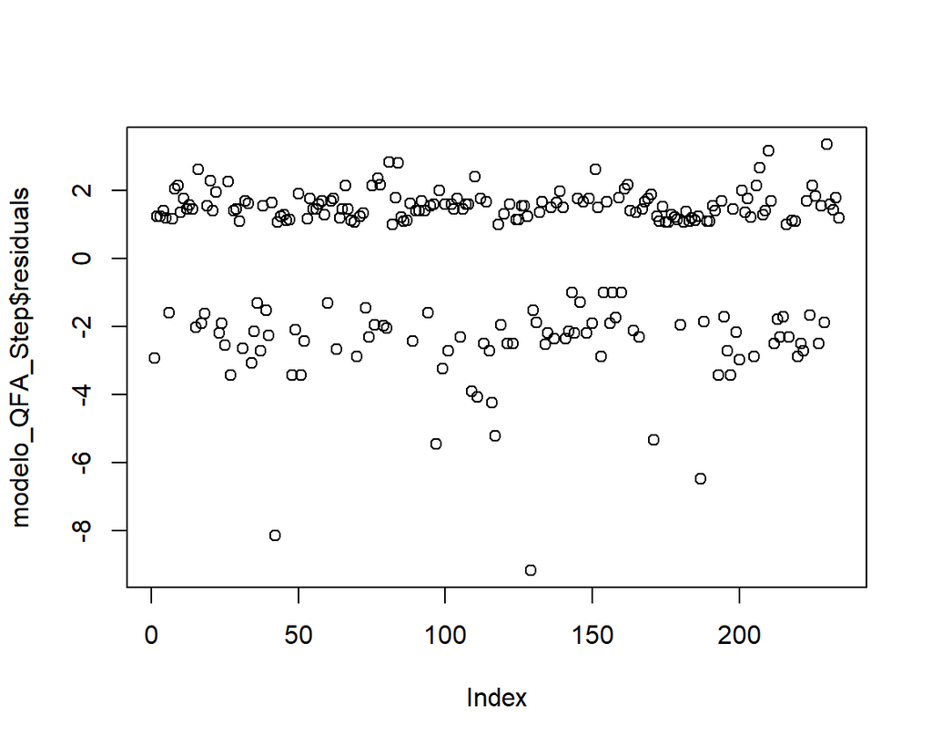

```r
plot(modelo_QFA_Step$residuals)
```

# PSV

**PSV**

```r
modelo_QFA_PSV <- glm(X48.2bin ~ X3+X10+X12+X32+X4+X7+X8+X11, data = dt, family = binomial)
```

### Resumo Estatístico

```r
summary(modelo_QFA_PSV)
```

```
Call:
glm(formula = X48.2bin ~ X3 + X10 + X12 + X32 + X4 + X7 + X8 +
    X11, family = binomial, data = dt)

Deviance Residuals:
    Min       1Q   Median       3Q      Max
-2.2219  -1.0952   0.5795   0.9363   1.6426

Coefficients:
              Estimate Std. Error z value Pr(>|z|)
(Intercept)    1.16207    1.27315   0.913   0.3614
X32            0.61261    0.96680   0.634   0.5263
X33           -0.94209    0.89528  -1.052   0.2927
X34           -0.86913    0.88857  -0.978   0.3280
X35           -1.23257    1.02155  -1.207   0.2276
X36           -1.09981    1.06704  -1.031   0.3027
X102           0.17539    0.35910   0.488   0.6253
X103          -1.02463    0.61361  -1.670   0.0949 .
X122          15.89094 1492.91670   0.011   0.9915
X123           0.19139    0.52788   0.363   0.7169
X124           0.10797    0.68673   0.157   0.8751
X125         -16.89371 1141.31188  -0.015   0.9882
X322           0.24133    0.33150   0.728   0.4666
X42            0.52504    0.37135   1.414   0.1574
X43            0.67095    0.66953   1.002   0.3163
X72           -0.64438    1.24866  -0.516   0.6058
X73            0.36392    0.89756   0.405   0.6851
X74            0.31648    0.88957   0.356   0.7220
X75            0.07585    0.97634   0.078   0.9381
X82           -0.63540    0.46603  -1.363   0.1727
X83           -0.93866    0.47767  -1.965   0.0494 *
X85           -0.95344    0.45389  -2.101   0.0357 *
X112          33.86198 2657.14282   0.013   0.9898
---
Signif. codes:  0 '***' 0.001 '**' 0.01 '*' 0.05 '.' 0.1 ' ' 1

(Dispersion parameter for binomial family taken to be 1)

    Null deviance: 308.84  on 233  degrees of freedom
Residual deviance: 266.25  on 211  degrees of freedom
AIC: 312.25

Number of Fisher Scoring iterations: 15
```

### ANOVA

```r
anova(modelo_QFA_PSV)
```

```
Analysis of Deviance Table

Model: binomial, link: logit

Response: X48.2bin

Terms added sequentially (first to last)


     Df Deviance Resid. Df Resid. Dev
NULL                   233     308.83
X3    5  14.7878       228     294.05
X10   2   4.8010       226     289.25
X12   4   5.8390       222     283.41
X32   1   1.4659       221     281.94
X4    2   2.4841       219     279.46
X7    4   1.8129       215     277.64
X8    3   5.4716       212     272.17
X11   1   5.9247       211     266.25
```

### Resíduos

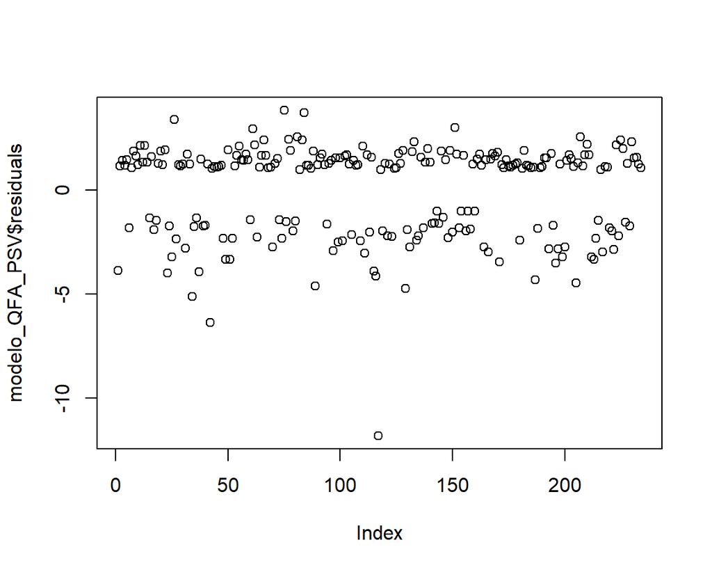

```r
plot(modelo_QFA_PSV$residuals)
```

# RF

**Random Forest**

Procedimento de seleção de variáveis de três etapas com base em florestas aleatórias para classificação supervisionada e problemas de regressão.

- A primeira etapa (“etapa de limiarização”) é dedicada a eliminar variáveis irrelevantes do conjunto de dados.

florestas aleatórias são calculadas usando a função randomForest com argumentos importância = TRUE, e nossa escolha de valores padrão para ntree e mtry (que são maiores do que o padrão em randomForest para obter mais medida de importância variável estável). Em seguida, as variáveis são classificadas de acordo com sua importância variável média (VI), em ordem decrescente. Essa ordem é mantida ao longo de todo o procedimento. Em seguida, um limite é calculado: min.thres, o valor mínimo previsto de uma árvore CART podada ajustada à curva dos desvios padrão de VI. Finalmente, a “etapa de limiar” real é realizada: apenas as variáveis com um VI médio maior que nmin * min.thres são mantidas.

- A segunda etapa (“etapa de interpretação”) visa selecionar todas as variáveis relacionadas à resposta para efeito de interpretação.

Segunda etapa (“etapa de interpretação”): são consideradas as variáveis selecionadas na primeira etapa. Os modelos de florestas aleatórias incorporados nfor.interp são desenvolvidos, começando com a construção da floresta aleatória apenas com a variável mais importante e terminando com todas as variáveis selecionadas na primeira etapa. Em seguida, err.min, o erro médio out-of-bag (OOB) mínimo desses modelos e seu desvio padrão associado sd.min são calculados. Finalmente, o menor modelo (e, portanto, suas variáveis correspondentes) com um erro OOB médio menor que err.min + nsd * sd.min é selecionado.

Observe que para esta etapa (e a próxima), o parâmetro mtry de randomForest é definido com seu valor padrão (consulte randomForest) se nvm, o número de variáveis no modelo, não for maior que o número de observações, embora seja definido como nvm / 3 caso contrário. Isso é para garantir a qualidade das estimativas de erro OOB ao longo dos modelos de RF incorporados.

A terceira etapa (“etapa de predição”) refina a seleção, eliminando a redundância no conjunto de variáveis selecionadas pela segunda etapa, para efeito de predição.

- Terceira etapa (“etapa de previsão”): o ponto de partida é o mesmo da segunda etapa. No entanto, agora as variáveis são adicionadas ao modelo de maneira gradual. mean.jump, o valor do salto médio é calculado usando variáveis que foram deixadas de fora pela segunda etapa e é definido como a diferença absoluta média entre os erros OOB médios de um modelo e seu primeiro modelo seguinte. Portanto, uma variável é incluída no modelo se a redução média do erro OOB for maior do que nmj * mean.jump.

Quanto à etapa de interpretação, o parâmetro mtry de randomForest é definido com seu valor padrão se nvm, o número de variáveis no modelo, não é maior que o número de observações, enquanto é definido como nvm / 3 caso contrário.

Feito utilizando o pacote `VSURF`, detalhes em https://hal.archives-ouvertes.fr/hal-01251924/

O pacote tem três opções para escolha das variáveis, são elas:

**varselect.thres** Um vetor de índices de variáveis selecionadas após a “etapa de limiarização”, classificadas de acordo com seu VI médio, em ordem decrescente.

**varselect.interp** Um vetor de índices de variáveis selecionadas após a “etapa de interpretação”.

**varselect.pred** Um vetor de índices de variáveis selecionadas após a “etapa de predição”.

Referêncial:

LOUPPE, Gilles et al. Understanding variable importances in forests of randomized trees. Advances in neural information processing systems, v. 26, p. 431-439, 2013.Disponível em: https://proceedings.neurips.cc/paper/2013/file/e3796ae838835da0b6f6ea37bcf8bcb7-Paper.pdf

```r
library(VSURF)
modelo_QFA_RF <- VSURF(x = dt[,-19], y = dt$X48.2bin, mtry = 200, RFimplem = "randomForest", na.action = na.fail)
```

```
Thresholding step
Estimated computational time (on one core): 15.5 sec.

Interpretation step (on 18 variables)
Estimated computational time (on one core): between 13.5 sec. and  36 sec.

Prediction step (on 1 variables)
Maximum estimated computational time (on one core): 0.7 sec.
```

```r
#help(VSURF)
```

### Modelo selecionado por **varselect.thres**

```r
modelo_QFA_RF$varselect.thres
```

```
 [1] 18  1  2  3  4  5  6  7  8  9 10 11 12 13 14 15 16 17
```

```r
modelo_QFA_RForest_VST <- glm(X48.2bin ~ X38+X1+X3+X2+X4+X5+X6+X7+X8+X9+X10+X11+X12+X22+X31+X32+X37, data = dd, family = binomial)
```

```r
modelo_QFA_RForest_VST
```

```
Call:  glm(formula = X48.2bin ~ X38 + X1 + X3 + X2 + X4 + X5 + X6 +
    X7 + X8 + X9 + X10 + X11 + X12 + X22 + X31 + X32 + X37, family = binomial,
    data = dd)

Coefficients:
(Intercept)          X38          X12          X32          X33          X34
    1.11185      0.16242      0.34276      1.45192     -0.28324     -0.37337
        X35          X36      X2negra      X2parda          X42          X43
   -1.00708     -0.44247      0.59357      0.56145      0.60543      0.76497
        X52          X53          X54          X55          X56          X62
   -0.71237     -1.26314     -1.11801     -0.50351     -1.27309     -1.47948
        X63          X64          X65          X72          X73          X74
   -1.44330     -1.31429     -0.68493     -0.52494      0.72865      1.02747
        X75          X82          X83          X85          X92          X93
    0.63499     -0.60636     -0.82074     -0.80598      0.75438      0.22827
        X94          X95         X102         X103         X112         X122
    0.54652      0.67814      0.27157     -0.71640     34.18351     16.76601
       X123         X124         X125         X224         X225         X312
    0.19912     -0.21186    -17.77351      0.22104      0.49670     -0.99823
       X322         X372
    0.07508     -0.10258

Degrees of Freedom: 266 Total (i.e. Null);  223 Residual
  (314 observations deleted due to missingness)
Null Deviance:      352.1
Residual Deviance: 285.7    AIC: 373.7
```

### Resumo Estatístico

```r
summary(modelo_QFA_RForest_VST)
```

```
Call:
glm(formula = X48.2bin ~ X38 + X1 + X3 + X2 + X4 + X5 + X6 +
    X7 + X8 + X9 + X10 + X11 + X12 + X22 + X31 + X32 + X37, family = binomial,
    data = dd)

Deviance Residuals:
    Min       1Q   Median       3Q      Max
-2.1509  -1.0045   0.5158   0.8623   1.9888

Coefficients:
              Estimate Std. Error z value Pr(>|z|)
(Intercept)    1.11185    2.65228   0.419   0.6751
X38            0.16242    0.13176   1.233   0.2177
X12            0.34276    0.31639   1.083   0.2787
X32            1.45192    0.84343   1.721   0.0852 .
X33           -0.28324    0.76108  -0.372   0.7098
X34           -0.37337    0.74671  -0.500   0.6171
X35           -1.00708    0.90969  -1.107   0.2683
X36           -0.44247    0.95317  -0.464   0.6425
X2negra        0.59357    0.47283   1.255   0.2093
X2parda        0.56145    0.35771   1.570   0.1165
X42            0.60543    0.38234   1.583   0.1133
X43            0.76497    0.70395   1.087   0.2772
X52           -0.71237    1.36487  -0.522   0.6017
X53           -1.26314    1.35954  -0.929   0.3528
X54           -1.11801    1.36948  -0.816   0.4143
X55           -0.50351    1.47129  -0.342   0.7322
X56           -1.27309    1.48257  -0.859   0.3905
X62           -1.47948    0.88006  -1.681   0.0927 .
X63           -1.44330    0.84134  -1.715   0.0863 .
X64           -1.31429    0.86426  -1.521   0.1283
X65           -0.68493    0.96345  -0.711   0.4771
X72           -0.52494    1.23126  -0.426   0.6699
X73            0.72865    1.06631   0.683   0.4944
X74            1.02747    1.07058   0.960   0.3372
X75            0.63499    1.15396   0.550   0.5821
X82           -0.60636    0.45514  -1.332   0.1828
X83           -0.82074    0.49346  -1.663   0.0963 .
X85           -0.80598    0.46775  -1.723   0.0849 .
X92            0.75438    1.52145   0.496   0.6200
```

[output cut: 11 more lines]

```
X225           0.49670    0.96939   0.512   0.6084
X312          -0.99823    0.53836  -1.854   0.0637 .
X322           0.07508    0.35334   0.213   0.8317
X372          -0.10258    0.32510  -0.316   0.7524
---
Signif. codes:  0 '***' 0.001 '**' 0.01 '*' 0.05 '.' 0.1 ' ' 1

(Dispersion parameter for binomial family taken to be 1)

    Null deviance: 352.11  on 266  degrees of freedom
Residual deviance: 285.71  on 223  degrees of freedom
  (314 observations deleted due to missingness)
AIC: 373.71

Number of Fisher Scoring iterations: 16
```

### ANOVA

```r
anova(modelo_QFA_RForest_VST)
```

```
Analysis of Deviance Table

Model: binomial, link: logit

Response: X48.2bin

Terms added sequentially (first to last)


     Df Deviance Resid. Df Resid. Dev
NULL                   266     352.11
X38   1   8.3267       265     343.78
X1    1   0.9475       264     342.83
X3    5  17.9834       259     324.85
X2    2   2.0641       257     322.78
X4    2   6.0657       255     316.72
X5    5   1.9233       250     314.79
X6    4   3.0400       246     311.75
X7    4   6.0749       242     305.68
X8    3   2.8800       239     302.80
X9    4   1.2137       235     301.59
X10   2   3.1630       233     298.42
X11   1   1.7397       232     296.68
X12   4   7.0301       228     289.65
X22   2   0.1573       226     289.50
X31   1   3.5930       225     285.90
X32   1   0.0911       224     285.81
X37   1   0.0997       223     285.71
```

### Resíduos

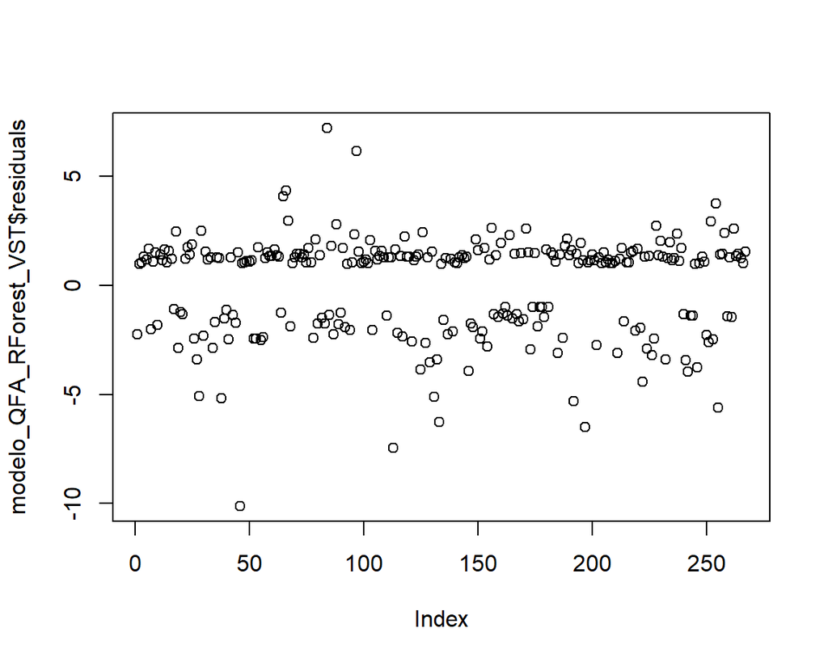

```r
plot(modelo_QFA_RForest_VST$residuals)
```

### Modelo selecionado por **varselect.interp**

```r
modelo_QFA_RF$varselect.interp
```

```
[1] 18
```

```r
modelo_QFA_RForest_VSI <- glm(X48.2bin ~ X38, data = dt, family = binomial)
```

```r
modelo_QFA_RForest_VSI
```

```
Call:  glm(formula = X48.2bin ~ X38, family = binomial, data = dt)

Coefficients:
(Intercept)          X38
    -0.9690       0.3034

Degrees of Freedom: 233 Total (i.e. Null);  232 Residual
Null Deviance:      308.8
Residual Deviance: 300.9    AIC: 304.9
```

### Resumo Estatístico

```r
summary(modelo_QFA_RForest_VSI)
```

```
Call:
glm(formula = X48.2bin ~ X38, family = binomial, data = dt)

Deviance Residuals:
    Min       1Q   Median       3Q      Max
-1.6905  -1.2829   0.8431   0.9552   1.3346

Coefficients:
            Estimate Std. Error z value Pr(>|z|)
(Intercept)  -0.9690     0.5553  -1.745  0.08100 .
X38           0.3034     0.1105   2.745  0.00605 **
---
Signif. codes:  0 '***' 0.001 '**' 0.01 '*' 0.05 '.' 0.1 ' ' 1

(Dispersion parameter for binomial family taken to be 1)

    Null deviance: 308.84  on 233  degrees of freedom
Residual deviance: 300.92  on 232  degrees of freedom
AIC: 304.92

Number of Fisher Scoring iterations: 4
```

### ANOVA

```r
anova(modelo_QFA_RForest_VSI)
```

```
Analysis of Deviance Table

Model: binomial, link: logit

Response: X48.2bin

Terms added sequentially (first to last)


     Df Deviance Resid. Df Resid. Dev
NULL                   233     308.83
X38   1   7.9145       232     300.92
```

### Resíduos

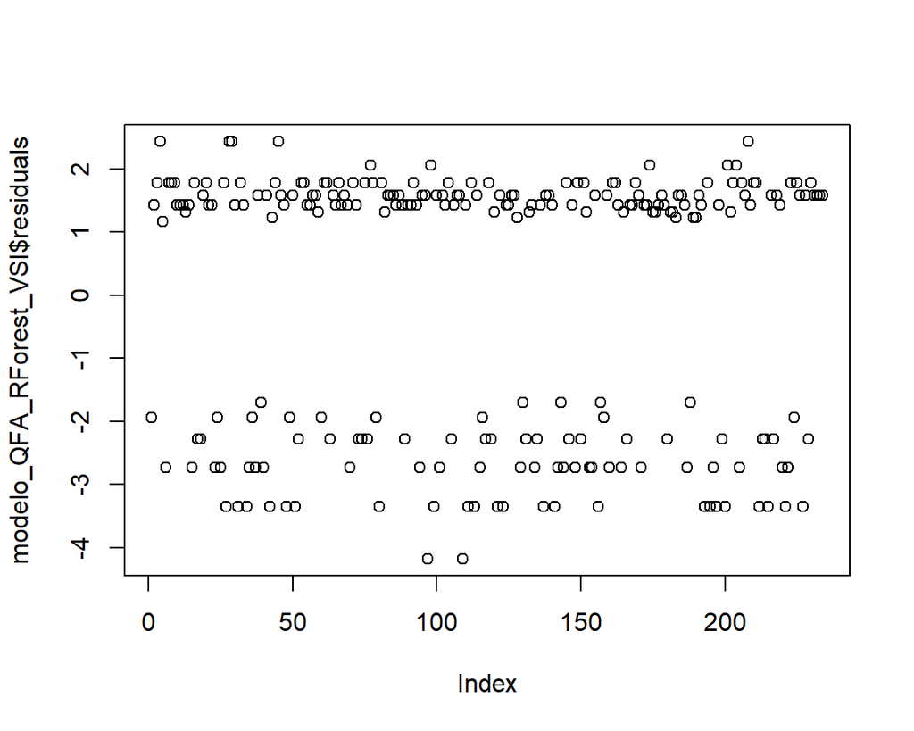

```r
plot(modelo_QFA_RForest_VSI$residuals)
```

### Modelo selecionado por **varselect.pred**

```r
modelo_QFA_RF$varselect.pred
```

```
[1] 18
```

```r
modelo_QFA_RForest_VSP <- glm(X48.2bin ~ X38, data = dt, family = binomial)
```

```r
modelo_EBIA_RForest_VSP
```

[output not shown]

### Resumo Estatístico

```r
summary(modelo_QFA_RForest_VSP)
```

```
Call:
glm(formula = X48.2bin ~ X38, family = binomial, data = dt)

Deviance Residuals:
    Min       1Q   Median       3Q      Max
-1.6905  -1.2829   0.8431   0.9552   1.3346

Coefficients:
            Estimate Std. Error z value Pr(>|z|)
(Intercept)  -0.9690     0.5553  -1.745  0.08100 .
X38           0.3034     0.1105   2.745  0.00605 **
---
Signif. codes:  0 '***' 0.001 '**' 0.01 '*' 0.05 '.' 0.1 ' ' 1

(Dispersion parameter for binomial family taken to be 1)

    Null deviance: 308.84  on 233  degrees of freedom
Residual deviance: 300.92  on 232  degrees of freedom
AIC: 304.92

Number of Fisher Scoring iterations: 4
```

### ANOVA

```r
anova(modelo_QFA_RForest_VSP)
```

```
Analysis of Deviance Table

Model: binomial, link: logit

Response: X48.2bin

Terms added sequentially (first to last)


     Df Deviance Resid. Df Resid. Dev
NULL                   233     308.83
X38   1   7.9145       232     300.92
```

### Resíduos

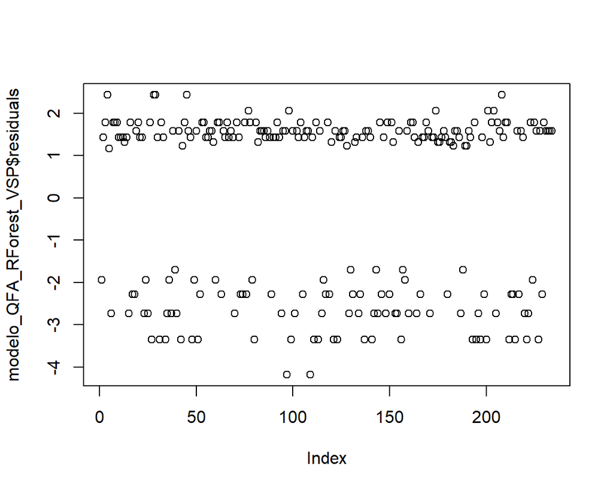

```r
plot(modelo_QFA_RForest_VSP$residuals)
```

# Lasso

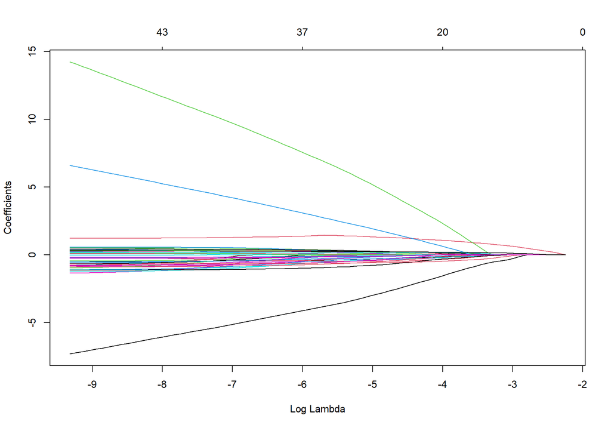

```r
x <- model.matrix(~ . - X48.2bin, data = dt)[,-1]
y <- cbind(dt$X48.2bin)
# Ajuste com penalização lasso
mlasso <- glmnet(x = x, y = y, family = "binomial", alpha = 1, grouped = FALSE)
# Traços
plot(mlasso, xvar = "lambda")
```

```r
# Validação cruzada para escolha do lambda
cv.lasso <- cv.glmnet(x,
                      y,
                      family = "binomial",
                      alpha = 1)
```

```r
cv.lasso$lambda.min
```

```
[1] 0.06037898
```

```r
cv.lasso$lambda.1se
```

```
[1] 0.105514
```

```r
coef(cv.lasso, s = cv.lasso$lambda.min)
```

```
45 x 1 sparse Matrix of class "dgCMatrix"
                    s1
(Intercept) 0.02082162
X12         .
X32         0.49744799
X33         .
X34         .
X35         .
X36         .
X2branca    .
X2negra     .
X2parda     .
X42         .
X43         .
X52         .
X53         .
X54         .
X55         .
X56         .
X62         .
X63         .
X64         .
X65         .
X72         .
X73         .
X74         .
X75         .
X82         .
X83         .
X85         .
X92         .
X93         .
X94         .
X95         .
X102        .
X103        .
X112        .
X122        .
X123        .
X124        .
X125        .
X224        .
X225        .
X312        .
X322        .
X372        .
X38         0.08344285
```

**Resultados**

```r
modelo_QFA_Lasso <- glm(X48.2bin ~ X32 + X38, data = dt, family = binomial)
```

| ### Figura 1 |
| --- |

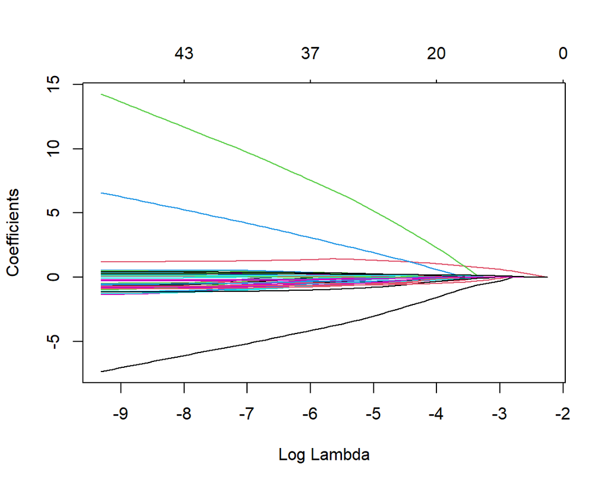

| ### Figura 2 |
| --- |

```r
plot(mlasso, xvar = "lambda")
```

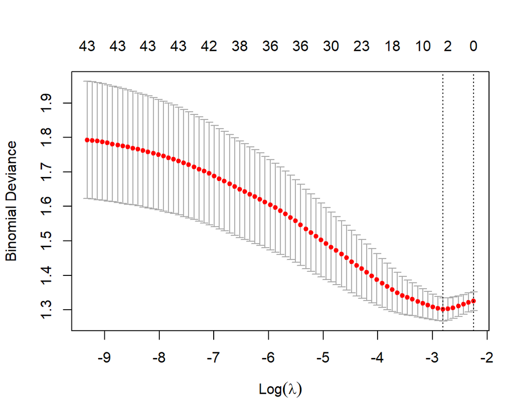

| ### Figura 3 |
| --- |

```r
plot(cv.lasso)
```

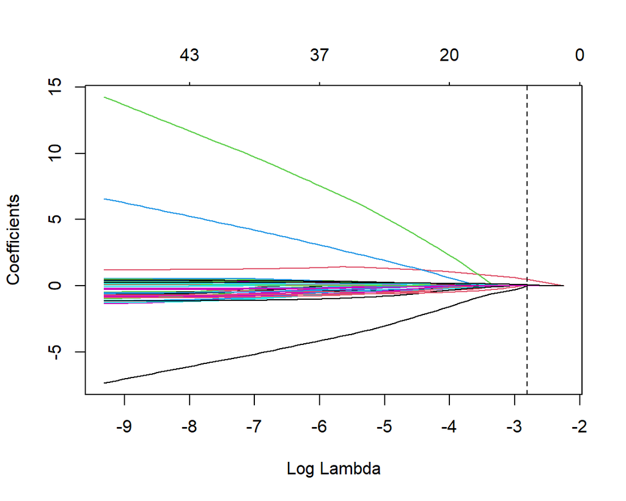

```r
plot(mlasso, xvar = "lambda")
abline(v = log(cv.lasso$lambda.min), lty = 2)
```

### Resumo Estatístico

```r
summary(modelo_QFA_Lasso)
```

```
Call:
glm(formula = X48.2bin ~ X32 + X38, family = binomial, data = dt)

Deviance Residuals:
    Min       1Q   Median       3Q      Max
-1.8207  -1.2634   0.7933   0.9586   1.4031

Coefficients:
            Estimate Std. Error z value Pr(>|z|)
(Intercept)  -1.1210     0.5666  -1.978  0.04789 *
X322          0.4510     0.2930   1.539  0.12376
X38           0.3023     0.1108   2.728  0.00637 **
---
Signif. codes:  0 '***' 0.001 '**' 0.01 '*' 0.05 '.' 0.1 ' ' 1

(Dispersion parameter for binomial family taken to be 1)

    Null deviance: 308.84  on 233  degrees of freedom
Residual deviance: 298.51  on 231  degrees of freedom
AIC: 304.51

Number of Fisher Scoring iterations: 4
```

### ANOVA

```r
anova(modelo_QFA_Lasso)
```

```
Analysis of Deviance Table

Model: binomial, link: logit

Response: X48.2bin

Terms added sequentially (first to last)


     Df Deviance Resid. Df Resid. Dev
NULL                   233     308.83
X32   1   2.5167       232     306.32
X38   1   7.8119       231     298.51
```

### Resíduos

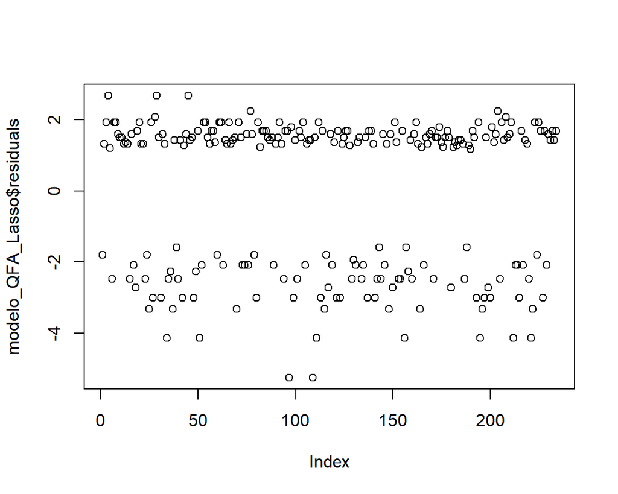

```r
plot(modelo_QFA_Lasso$residuals)
```

# Comparação

```r
nomes <- c("RForest_VST","RForest_VSI","RForest_VSP","Lasso","Stepwise","PSV")
AIC <- c(summary(modelo_QFA_RForest_VST)$aic,summary(modelo_QFA_RForest_VSI)$aic,summary(modelo_QFA_RForest_VSP)$aic,
         summary(modelo_QFA_Lasso)$aic,summary(modelo_QFA_Step)$aic,summary(modelo_QFA_PSV)$aic)

Residual_Deviance <- c(summary(modelo_QFA_RForest_VST)$deviance,summary(modelo_QFA_RForest_VSI)$deviance,summary(modelo_QFA_RForest_VSP)$deviance,
         summary(modelo_QFA_Lasso)$deviance,summary(modelo_QFA_Step)$deviance,summary(modelo_QFA_PSV)$deviance)

Gl_Residual_Deviance <- c(summary(modelo_QFA_RForest_VST)$df.residual,summary(modelo_QFA_RForest_VSI)$df.residual,summary(modelo_QFA_RForest_VSP)$df.residual,
         summary(modelo_QFA_Lasso)$df.residual,summary(modelo_QFA_Step)$df.residual,summary(modelo_QFA_PSV)$df.residual)

tabela <- cbind(nomes,AIC,Residual_Deviance,Gl_Residual_Deviance)
kable(tabela)
```

| nomes | AIC | Residual_Deviance | Gl_Residual_Deviance |
| --- | --- | --- | --- |
| RForest_VST | 373.71187271338 | 285.71187271338 | 223 |
| RForest_VSI | 304.920620343795 | 300.920620343795 | 232 |
| RForest_VSP | 304.920620343795 | 300.920620343795 | 232 |
| Lasso | 304.506447499118 | 298.506447499118 | 231 |
| Stepwise | 300.52103990726 | 272.52103990726 | 220 |
| PSV | 312.248121998481 | 266.248121998481 | 211 |

[output not shown]

# Proximos Passos

Frank Harrell’s Regression Modeling Strategies. **Ler**

- Metrica para avaliar os modelos. **(COnfirmar no trabalho do Gilberto o método de avaliação) - Usou a função `performace/prediction`**
- Analise de resíduos. **(?? plot$residuals?)**
- Melhor modelo para predição(RMSE). **(COnfirmar no trabalho do Gilberto o método de avaliação) - Usou a função `performace/prediction`**
- Tabela RMSE, AIC, Deviance Residual, GLResidual. **(OK)**
- Tabela com as covariáveis Selecionadas. **(OK)**
- Quais métodos coincidem com relação as variáveis. **(OK)**
- Modelo com arvore (setseed). **Pendente**
- DIferença entre os três critérios do pacote `SURF`. **(OK)**
- Tabela com tecnicas e variáveis selecionadas. **(OK)**
- Retirar variável com muitos NA. (X33 - EBIA / QFA) por inconsistencia nas catégoria e alta frequência de NA **(OK)**
- Refazer o ajuste **(OK)**
- Estudar Simulação em PVS (Bursac - mandar email) **(Pendente)**